# Sprawozdanie

Bartłomiej Fatyga

10 marca 2018

## 1. Wprowadzenie i hipotezy.

Celem sprawozdania jest badanie mocy trzech testów normalności (Shapiro-Wilka, Kołmogorowa-Smirnowa, Jarque-Bera) w przypadku, gdy dane pochodzą z rozkładu t-Studenta w zależności od:

- Długości próby,
- Ilości stopni swobody w rozkładzie t
- Poziomu istotności wybranego testu.

Dla poszczególnych testów celem badania jest również sprawdzenie hipotez:

- Shapiro-Wilka
  - Test normalności Shapiro-Wilka ma największą moc spośród badanych testów.
  - Wartości uzyskane w wyniku przeprowadzenia testu Shapiro-Wilka w dużym stopniu zależą od wielkości próby.
- Kołmogorowa-Smirnowa
  - Wartości uzyskane w wyniku przeprowadzenia testu Kołmogorowa-Smirnowa w dużym stopniu zależą od ilości stopni swobody w badanym rozkładzie.
- Jarque-Bera
  - Wartości uzyskane w wyniku przeprowadzenia testu Jarque-Bera w dużym stopniu zależą od przyjętego poziomu istotności.

### Test Shapiro-Wilka

Bardzo popularny test służący do sprawdzania normalności rozkładu zmiennej losowej. Po raz pierwszy został opublikowany w 1965 roku przez **Samuela Shapiro** i **Martina Wilka**. Test opiera się na wykresie kwantylowym i jest znany ze względu na dużą moc (co zamierzam udowodnić). Hipotezy tego testu są następującej postaci:

*H0: Rozkład badanej cechy jest rozkładem normalnym.*

*H1: Rozkład badanej cechy nie jest rozkładem normalnym.*

Przykładowy wykres kwantylowy:

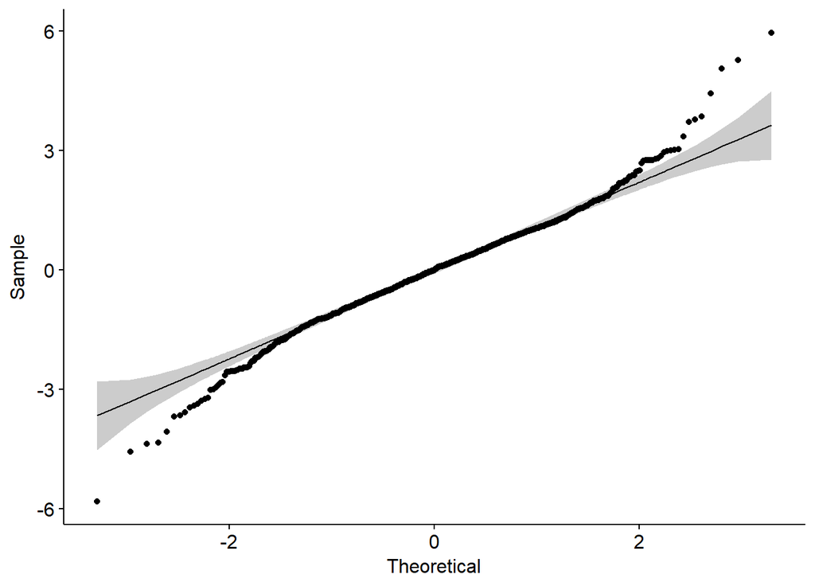

```r
ggqqplot(rt(1000, 5))
```

Ze względu na specyfikę testu zdecydowałem się na następujące wartości próby:

```r
#Ilość symulacji
N <- 1000
#Rozpatrywane stopnie swobody
dfs <- seq(5, 50, by = 5)
#Rozpatrywane poziomy istotności
alphas <- c(.001, .01, .05, .1)
#Długości próby
sample_l <- c(10,20,30,50,100,200,300,400,500,1000,2000) #Zdecydowałem się na własne wartości, by jak najbardziej ukazać zależność od długości próby
```

### Test Kołmogorowa-Smirnowa

Test Kołmogorowa-Smirnowa służy do badania zgodności danych z rozkładem ciągłym (w naszym przypadku z rozkładem normalnym). Nazwa testu wzięła sią od nazwisk dwóch rosyjskich statystyków: **Andrey’a Kołmogorowa** oraz **Nikolai’a Smirnowa**. Metoda ta opiera się na badaniu odległości między hipotetyczną dystrybuantą, a rzeczywistą. Dużą zaletą testu jest możliwośc wykorzystania go dla bardzo nielicznych prób. Hipotezy są następującej postaci:

*H0: cecha X ma dystrybuantę F*

*H1: cecha X nie ma dystrybuanty F*

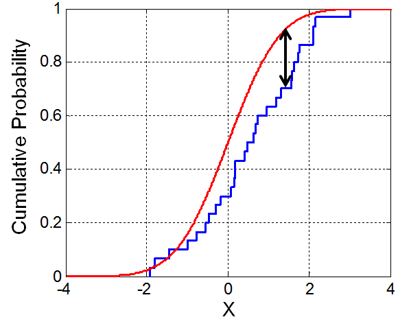

Zdecydowałem się na następujące wartości próby:

```r
#Ilość symulacji
N <- 1000
#Rozpatrywane stopnie swobody
dfs <- seq(2, 20, by = 2)#Należy zwrócić uwagę, ze liczba stopni swobody uległa redukcji
#Rozpatrywane poziomy istotności
alphas <- c(.001, .01, .05, .1)
#Długości próby
sample_l <- c(10,20,30,50,100,200,300,400,500,1000,2000)
```

### Test Jarque-Bera

Ostatni z badanych przeze mnie testów. Został nazwany tak, by uczcić dwóch statystków: meksykanina **Carlosa Jarque** oraz amerykanian **Anil’a K.Bera**. Metoda ta opiera się na obserwacji, że rozkład normalny jest symetrczyny oraz jego kurtoza wynosi 3. Do jego obliczania stosuje się wartości trzeciego i czwartego momentu centralnego reszt modelu. Hipotezy dla tego testu prezentują się następująco:

*H0: składnik resztowy posiada rozkład normalny*

*H1: składnik resztowy nie posiada rozkładu normalnego*

Wybrane przeze mnie wartości próby służace do badnia mocy tego testu:

```r
#Ilość symulacji
N <- 1000
#Rozpatrywane stopnie swobody
dfs <- seq(5, 50, by = 5)
#Rozpatrywane poziomy istotności
alphas <- c(.001, .01, .05, .1)
#Długości próby
sample_l <- c(10,20,30,50,100,200,300,400,500,1000,2000)
```

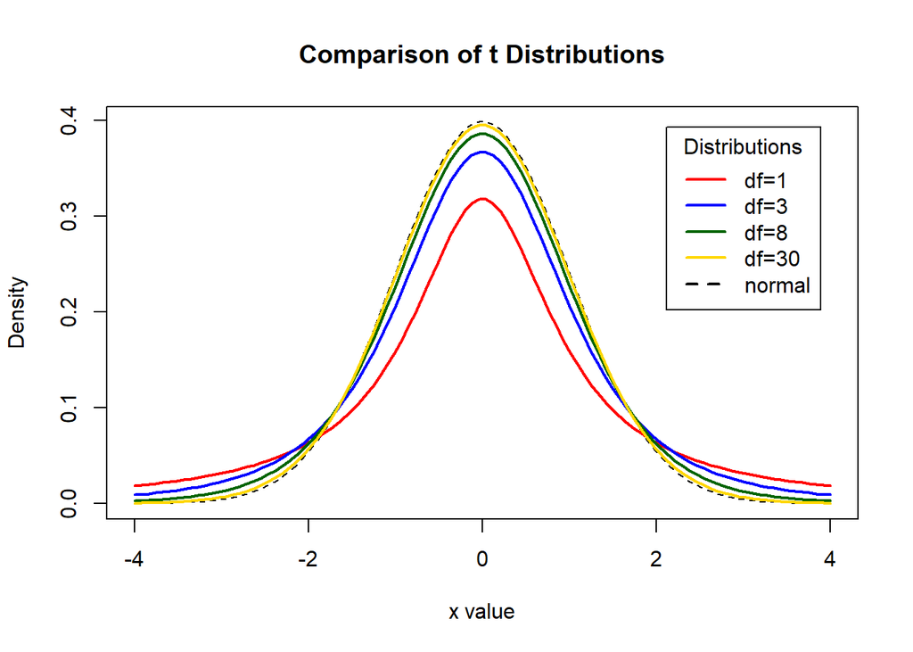

## Uzyskane wyniki

### Test Shapiro-Wilka

```r
glimpse(params)
```

```
## Observations: 440
## Variables: 3
## $ df     <dbl> 5, 10, 15, 20, 25, 30, 35, 40, 45, 50, 5, 10, 15, 20, 2...
## $ alpha  <dbl> 0.001, 0.001, 0.001, 0.001, 0.001, 0.001, 0.001, 0.001,...
## $ length <dbl> 10, 10, 10, 10, 10, 10, 10, 10, 10, 10, 10, 10, 10, 10,...
```

Przeprowadzenie symulacji:

```r
set.seed(100)
now <- Sys.time()
powers <- sapply(1:nrow(params), function(p){
  df <- params[p, 1]
  alpha <- params[p, 2]
  l <- params[p, 3]
  p_sim <-sapply(rep(df, N), function(x){
    my_sample <- rt(l, df)
    shapiro.test(my_sample)$p.value
  })
  mean(p_sim < alpha)
})
Sys.time() - now
```

```
## Time difference of 1.52738 mins
```

Uzyskane wyniki:

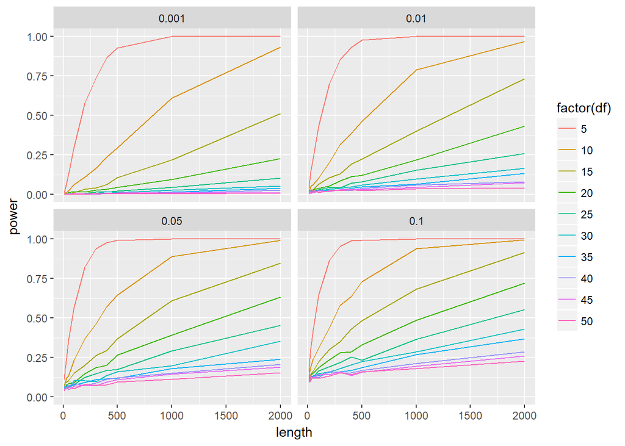

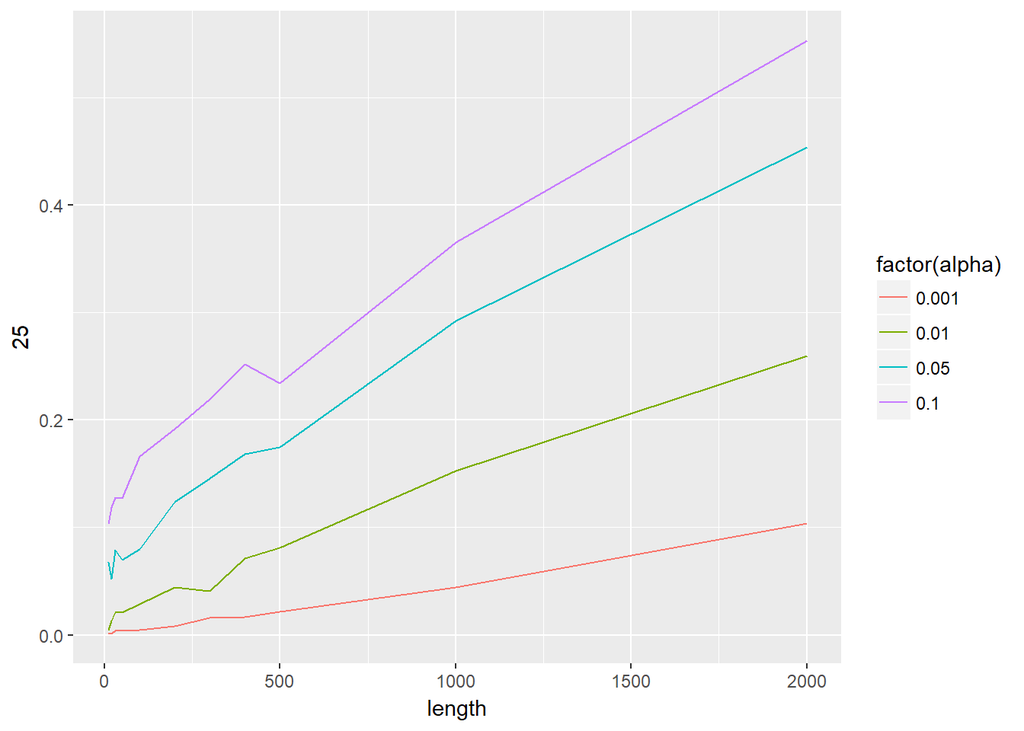

### Test Kołmogorowa-Smirnowa

```r
glimpse(params)
```

```
## Observations: 440
## Variables: 3
## $ df     <dbl> 2, 4, 6, 8, 10, 12, 14, 16, 18, 20, 2, 4, 6, 8, 10, 12,...
## $ alpha  <dbl> 0.001, 0.001, 0.001, 0.001, 0.001, 0.001, 0.001, 0.001,...
## $ length <dbl> 10, 10, 10, 10, 10, 10, 10, 10, 10, 10, 10, 10, 10, 10,...
```

Przeprowadzenie symulacji:

```r
set.seed(100)
now <- Sys.time()
powers <- sapply(1:nrow(params), function(p){
  df <- params[p, 1]
  alpha <- params[p, 2]
  l <- params[p, 3]
  p_sim <-sapply(rep(df, N), function(x){
    my_sample <- rt(l, df)
    ks.test(my_sample, "pnorm")$p.value
  })
  mean(p_sim < alpha)
})
Sys.time() - now
```

```
## Time difference of 2.083643 mins
```

Uzyskane wyniki:

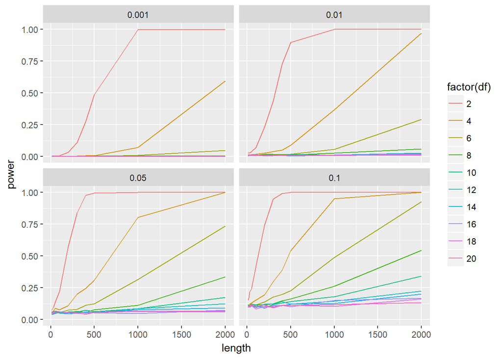

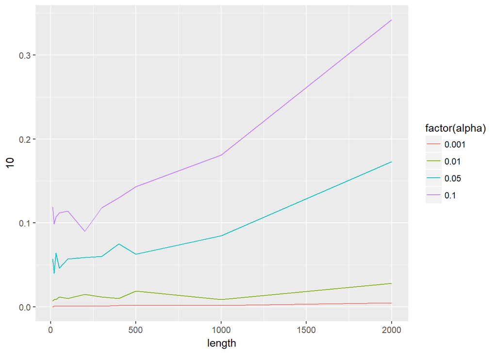

### Test Jarque-Bera

```r
glimpse(params)
```

```
## Observations: 440
## Variables: 3
## $ df     <dbl> 5, 10, 15, 20, 25, 30, 35, 40, 45, 50, 5, 10, 15, 20, 2...
## $ alpha  <dbl> 0.001, 0.001, 0.001, 0.001, 0.001, 0.001, 0.001, 0.001,...
## $ length <dbl> 10, 10, 10, 10, 10, 10, 10, 10, 10, 10, 10, 10, 10, 10,...
```

Przeprowadzenie symulacji:

```r
set.seed(100)
now <- Sys.time()
powers <- sapply(1:nrow(params), function(p){
  df <- params[p, 1]
  alpha <- params[p, 2]
  l <- params[p, 3]
  p_sim <-sapply(rep(df, N), function(x){
    my_sample <- rt(l, df)
    jarque.bera.test(my_sample)$p.value
  })
  mean(p_sim < alpha)
})
Sys.time() - now
```

```
## Time difference of 1.247755 mins
```

Uzyskane wyniki:

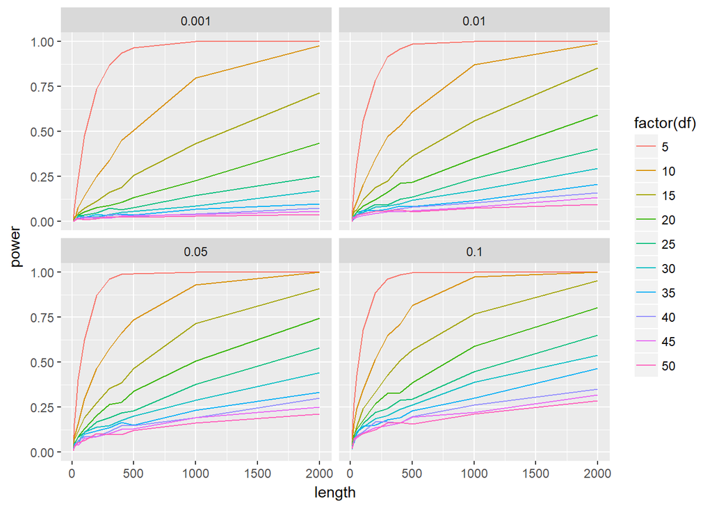

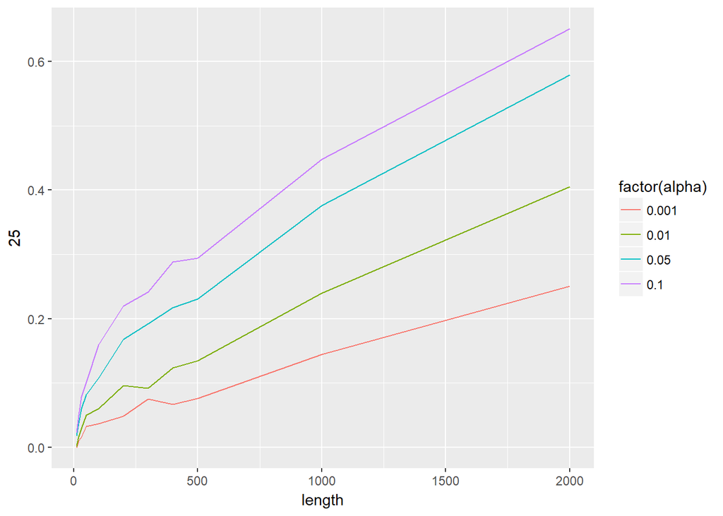

## Wnioski

Z przeprowadzonej analizy możemy wysnuć parę interesujących wniosków:

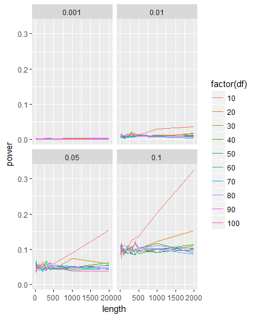

- Dość oczywistym wnioskiem jest natomiast stwierdzenie, że test Kołmogorowa-Smirnowa charakteryzuje się **mniejszą mocą**, niż pozostałe badane testy.
- W przypadku testu Jarque-Bera możemy potwierdzić hipotezę, iż wartości uzyskane w wyniku przeprowadzenia testu Jarque-Bera w **dużym stopniu zależą** od przyjętego poziomu istotności. Skoki między kolejnymi poziomami istotności są widoczne, jednak nie jest to szczególna cecha tego testu i nie wyróżnia się nią znacznie spośród pozostałych.

### Czynniki które mogły wpłynąć na uzyskane wyniki

Badając moc testów należy zwrócić uwagę na wiele bardzo istotnych czynników. Każdy test posiada inną charakterystykę, którą należy wziąć pod uwagę badając go (np. test Shapiro-Wilka sprawdza się dla liczebności próby od 3 do 5000). Na uzyskane przez mnie wyniki przede wszystkim wpłynęły dobrane przeze mnie wartości próby. Przy źle dobranych wartościach wykresy dla poszczególnych testów “nachodziłyby” na siebie, z kolei jeśli wartości byłby zbyt “dopasowane” nie bylibyśmy w stanie zaobserwować zależności. Dodatkowo wszystkie wartości podjęte obserwacji są uzyskane w wyniku algorytmu komputerowego więc nie możemy powiedzieć, że są w pełni losowe. Duże znacznie dla badania miały również ograniczenia sprzętowe. Dokładniejsze wyniki uzyskalibyśmy zwiększając liczbę symulacji, czy zwiększając rozpiętość wartości próby, jednak w tym przypadku czas działania skryptu znacznie by się zwiększył.